# Investigate Nicolo Aurisano's Workflow: LCIA QSAR Project

**Date:** April 13 2023  
**Authors:** Jacob Kvasnicka & Prof. Weihsueh A. Chiu

Previously, I showed preliminary results comparing the performances of different supervised machine learning estimators at predicting oral point of departures. These performances appeared to be less favorable than a workflow implemented by Nicolo Aurisano in 2021.

This notebook investigates the discrepancy in model performances (R2) between QSAR modeling workflows. For each workflow, a Random Forest regression estimator is implemented with a repeated internal cross-validation involving 50 randomized repeats of 5 partitions to the data.

### Overview of workflows

Using the data from Nicolo,

**1. Nicolo's workflow**: A reproduction of the analysis by Nicolo Aurisano in the RMD file, "RF BMD25 ALL"

**2. Nicolo's workflow, no duplicates**: Same as (1) excluding duplicated chemicals (keeping the first duplicate).

**3. Nicolo's workflow, no duplicates, mixtures or metals**: Same as (2) after applying our chemical filter.

**4. Our workflow, all features**: Uses the same dataset as Nicolo, but applies our draft pipeline for feature preprocessing which involves imputation of missing values, etc.

**5. Our workflow, median LD50**: Same as (4) with only one of the three LD50 features: Median experimental.

**6. Our workflow, geo. mean LD50**: Same as (4) with only one of the three LD50 features: Geometric mean experimental.

**7. Our workflow, TEST LD50**: Same as (4) with only one of the three LD50 features: TEST-predicted.

```python
import pandas as pd
import numpy as np
from os import path
from sklearn.impute import SimpleImputer
from sklearn.ensemble import RandomForestRegressor
from sklearn.pipeline import Pipeline
from sklearn import metrics
import matplotlib.pyplot as plt
import seaborn as sns

import parse

# Enable modules to be imported from the parent directory.
import sys
sys.path.append('..')
from common.transform import (
    BasicFeatureSelector,
    Log10Transformer,
    SelectiveScaler
)
from common import (
    features,
    learn,
    plot,
    comptox
)

index_col = 'DTXSID'
```

## Define some helper functions

```python
def repeated_kfold(estimator, X, y, n_splits=5, n_repeats=50, random_state=1):
    '''Helper function which implements a repeated k-fold cross-validation.
    '''
    # Use numpy.ndarray type exclusively.
    if hasattr(X, 'index'):
        X = X.to_numpy()
    if hasattr(y, 'index'):
        y = y.to_numpy().flatten()

    return learn.repeated_kfold(
        estimator,
        X,
        y,
        learn.regression_metrics,
        n_splits=n_splits,
        n_repeats=n_repeats,
        random_state=random_state
    )

def original_filter(data, columns):
    '''Apply the original filter used by Nicolo.
    '''
    data = study_count_filter(data)
    return missing_values_filter(data, columns)

def study_count_filter(data):
    '''Drop chemicals with insufficient study counts.
    '''
    where_sufficient = data['Count_nrd'] > 3
    return data.loc[where_sufficient]

def missing_values_filter(data, columns):
    '''Drop chemicals for which any of the specified columns contain missing values.
    '''
    where_not_missing = data[columns].notna().all(axis=1)
    return data.loc[where_not_missing]

def drop_duplicates_and_metals(data):
    '''Drop chemicals that are duplicated and/or contain metal.
    '''
    data = drop_duplicates(data)
    return data.drop(get_metals_or_missing_formula(data))

def drop_duplicates(data):
    '''Drop chemicals that are duplicated.
    '''
    return data.loc[~data.index.duplicated(keep='first')]

def get_metals_or_missing_formula(data):
    '''Return a list of any metals in index.
    '''
    return comptox.chemicals_to_exclude_from_qsar(data['MOLECULAR_FORMULA'])

def get_duplicates(data):
    '''Return a list of any duplicates in the index.
    '''
    where_duplicated = data.index.duplicated(keep='first')
    return list(data.loc[where_duplicated].index)
```

## Inspect the data used by Nicolo Aurisano

### Load the features and target variable

```python
## Use DTXSID as the chemical identifier (index).

identifiers_path = path.join(
    'Source',
    'CompTox',
    'CCD-identifiers.csv')

identifier_columns = [
    'DTXSID',
    'CASRN',
]
chem_identifiers = (
    pd.read_csv(identifiers_path)
    [identifier_columns]
)
```

```python
nicolo_data_path = path.join(
    'Source',
    'Input_ALL_V01a.xlsx')

# Define key-word arguments for pandas.read_excel().
kwargs = {
    'sheet_name': 'data',
    'header': 0}

feature_columns = [
    'MASS',
    'LD50_T',
    'ATM_O',
    'BIOC_O',
    'BIOD_O',
    'BP_O',
    'HL_O',
    'KM_O',
    'LOGKOA_O',
    'KOC_O',
    'LOGP_O',
    'MP_O',
    'VP_O',
    'WS_O',
    'LOG_M_LD50',
    'LOG_G_LD50',
]
target_column = ['logBMD25_nrd']

nicolo_data = (
    pd.read_excel(nicolo_data_path, **kwargs)
    .set_index('CAS_CORRECTED')
    .join(
        chem_identifiers.set_index('CASRN'),
        how='inner')
    .set_index('DTXSID')
)

nicolo_data[feature_columns + target_column]
```

| DTXSID | MASS | LD50_T | ATM_O | BIOC_O | BIOD_O | BP_O | HL_O | KM_O | LOGKOA_O | KOC_O | LOGP_O | MP_O | VP_O | WS_O | LOG_M_LD50 | LOG_G_LD50 | logBMD25_nrd |
| --- | --- | --- | --- | --- | --- | --- | --- | --- | --- | --- | --- | --- | --- | --- | --- | --- | --- |
| DTXSID5020281 | 157.550 | 0.007079 | 7.429490e-13 | 20.11010 | 4.84081 | 242.050 | 4.947790e-06 | 0.332365 | 4.32722 | 507.6930 | 2.39154 | 82.9942 | 2.203470e-02 | 1.317610e-03 | 2.132503 | 1.874228 | -1.098677 |
| DTXSID8020961 | 138.126 | 0.009141 | 1.480110e-12 | 3.47311 | 6.64833 | 331.672 | 1.265030e-09 | 0.306715 | 6.57226 | 75.9962 | 1.38804 | 145.5400 | 3.265100e-06 | 4.815930e-03 | 2.160703 | 2.065629 | -0.231734 |
| DTXSID0021834 | 139.110 | 0.005140 | 1.155450e-12 | 11.35610 | 4.09570 | 278.910 | 4.207650e-10 | 0.251436 | 6.11321 | 233.1200 | 1.91211 | 113.5640 | 9.970590e-05 | 9.679290e-02 | 1.749938 | 1.913799 | NaN |
| DTXSID2044347 | 150.177 | 0.004887 | 7.147800e-12 | 7.55058 | 4.91679 | 248.981 | 9.683370e-08 | 0.279812 | 5.07316 | 98.5113 | 1.74292 | 37.4772 | 6.500820e-03 | 1.201570e-02 | 2.623739 | 2.623739 | NaN |
| DTXSID9059204 | 170.590 | 0.008222 | 1.280200e-11 | 12.93020 | 4.52465 | 262.457 | 8.829520e-08 | 0.318916 | 5.78333 | 109.5910 | 2.32425 | 24.6003 | 9.898050e-03 | 4.557770e-03 | 2.714817 | 2.714817 | NaN |
| ... | ... | ... | ... | ... | ... | ... | ... | ... | ... | ... | ... | ... | ... | ... | ... | ... | ... |
| DTXSID6057879 | 345.460 | 0.001766 | 2.014600e-11 | 20.26340 | 6.00889 | 417.425 | 1.882080e-07 | 1.137960 | 10.52190 | 881.4960 | 3.72958 | 181.8440 | 1.564390e-08 | 4.541010e-07 | NaN | NaN | 1.169105 |
| DTXSID5057880 | 353.860 | NaN | 1.382820e-11 | 96.57770 | 3.35362 | 415.812 | 2.941970e-07 | 1.655430 | 10.64380 | 961.6230 | 2.95065 | 125.4470 | 6.420140e-08 | 5.643740e-07 | NaN | NaN | 1.169105 |
| DTXSID5057882 | 300.150 | NaN | 1.594230e-11 | 225.96200 | 3.54031 | 337.893 | 2.333810e-07 | 3.627750 | 10.62620 | 8156.8700 | 3.84550 | 161.2890 | 2.468280e-07 | 1.982760e-06 | NaN | NaN | 0.955192 |
| DTXSID5057884 | 409.310 | NaN | 2.432130e-11 | 82.99380 | 6.80176 | 375.225 | 1.494930e-10 | 0.148214 | 9.54575 | 2186.0300 | 2.90792 | 181.9450 | 1.335850e-09 | 3.015700e-05 | NaN | NaN | 0.277901 |
| DTXSID0057885 | 481.519 | NaN | 2.491050e-11 | 19.04870 | 5.27344 | 346.531 | 6.479200e-10 | 1.686170 | 9.67654 | 161483.0000 | 5.49079 | 168.4210 | 2.338530e-09 | 3.245060e-08 | NaN | NaN | 0.464056 |

7098 rows × 17 columns

```python
duplicates = get_duplicates(nicolo_data[feature_columns + target_column])

percent_duplicates = round(
    len(duplicates)
    / len(nicolo_data)
    * 100
)

print(f'{percent_duplicates}% of all chemicals are duplicates')
identifier_subset =  ['MOLECULAR_FORMULA', 'PREFERRED_NAME']
nicolo_data.loc[duplicates, identifier_subset]
```

```
9% of all chemicals are duplicates
```

| DTXSID | MOLECULAR_FORMULA | PREFERRED_NAME |
| --- | --- | --- |
| DTXSID7074953 | C14H26O2 | Dodecanoic acid, ethenyl ester |
| DTXSID7074953 | C14H26O2 | Dodecanoic acid, ethenyl ester |
| DTXSID7058333 | NaN | Hexanoic acid, 2-ethyl-, copper salt (1:?) |
| DTXSID7058333 | NaN | Hexanoic acid, 2-ethyl-, copper salt (1:?) |
| DTXSID3024102 | C13H22NO3PS | Fenamiphos |
| ... | ... | ... |
| DTXSID60862363 | C11H23NO4 | N-(3-Ethoxypropyl)-2,4-dihydroxy-3,3-dimethylb... |
| DTXSID2049424 | C9H16N2 | 1,8-Diazabicyclo[5.4.0]undec-7-ene |
| DTXSID2049424 | C9H16N2 | 1,8-Diazabicyclo[5.4.0]undec-7-ene |
| DTXSID0024343 | C22H19Br4NO3 | Tralomethrin |
| DTXSID0024343 | C22H19Br4NO3 | Tralomethrin |

1228 rows × 2 columns

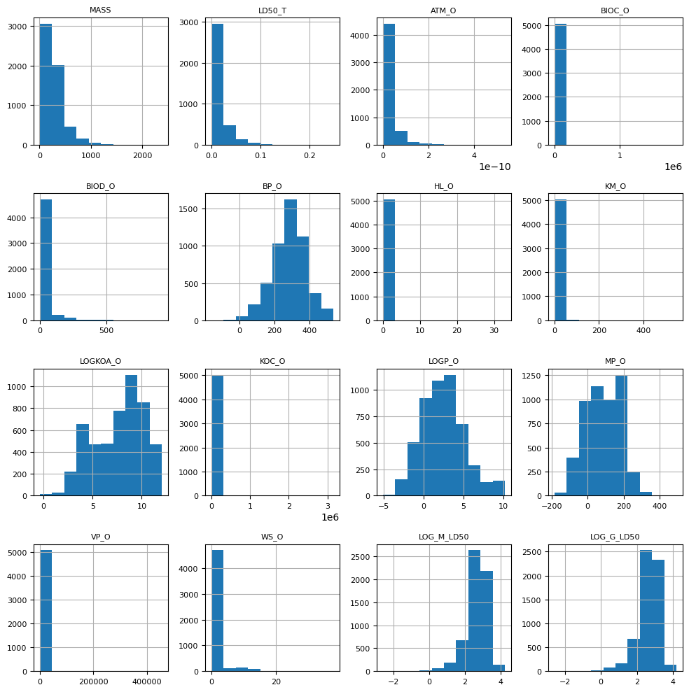

```python
_ = plot.histograms_for_columns(
    nicolo_data[feature_columns],
    figsize=(10., 10.))
```

I kept the features in their original state to reproduce Nicolo's workflow. Our workflow includes a preprocessing step that performs log-10 transformation to any features that are significantly positively skewed based on a skew test. To avoid redundant transformations, I could set all input features in their original, untransformed scales, and let the preprocessing pipeline handle all transformations.

```python
# Inverse transform log-scale columns to avoid redundancy. Assume base 10.
log_columns = [c for c in nicolo_data[feature_columns] if 'LOG' in c]
nicolo_data.loc[:, log_columns] = 10**nicolo_data[log_columns]
```

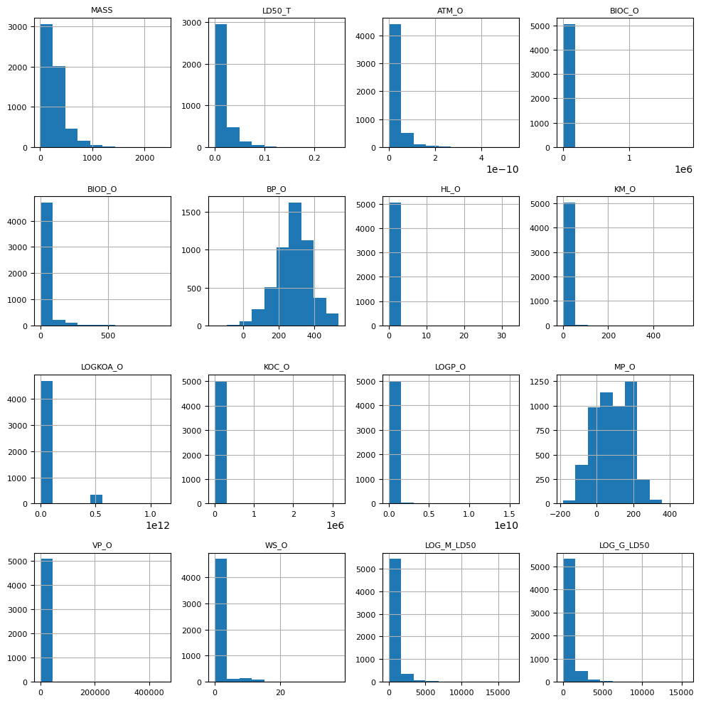

```python
_ = plot.histograms_for_columns(
    nicolo_data[feature_columns],
    figsize=(10., 10.))
```

### Apply the original filter

Drop chemicals with insufficient study counts. Then, drop chemicals with any missing values.

```python
data_filtered_original = original_filter(nicolo_data, feature_columns + target_column)

data_filtered_original[feature_columns + target_column]
```

| DTXSID | MASS | LD50_T | ATM_O | BIOC_O | BIOD_O | BP_O | HL_O | KM_O | LOGKOA_O | KOC_O | LOGP_O | MP_O | VP_O | WS_O | LOG_M_LD50 | LOG_G_LD50 | logBMD25_nrd |
| --- | --- | --- | --- | --- | --- | --- | --- | --- | --- | --- | --- | --- | --- | --- | --- | --- | --- |
| DTXSID5020281 | 157.550 | 0.007079 | 7.429490e-13 | 20.11010 | 4.84081 | 242.050 | 4.947790e-06 | 0.332365 | 2.124320e+04 | 507.69300 | 2.463429e+02 | 82.9942 | 2.203470e-02 | 0.001318 | 135.676139 | 74.856268 | -1.098677 |
| DTXSID8020961 | 138.126 | 0.009141 | 1.480110e-12 | 3.47311 | 6.64833 | 331.672 | 1.265030e-09 | 0.306715 | 3.734737e+06 | 75.99620 | 2.443656e+01 | 145.5400 | 3.265100e-06 | 0.004816 | 144.778249 | 116.313204 | -0.231734 |
| DTXSID2026652 | 162.276 | 0.029444 | 1.439500e-11 | 1747.09000 | 7.94260 | 205.830 | 1.256430e-02 | 3.978540 | 1.520407e+05 | 2084.28000 | 1.820162e+04 | -45.5895 | 2.476330e-01 | 0.000007 | 782.276836 | 907.751857 | 1.042817 |
| DTXSID6026080 | 166.132 | 0.023550 | 3.317970e-12 | 5.04642 | 6.64541 | 318.732 | 1.626090e-09 | 0.357494 | 6.909872e+07 | 30.63220 | 9.682110e+01 | 284.7150 | 9.148410e-06 | 0.000093 | 1222.307556 | 1216.331850 | 1.842616 |
| DTXSID3021437 | 108.184 | 0.022233 | 1.269450e-10 | 165.56600 | 3.88538 | 128.086 | 6.232450e-03 | 0.388963 | 3.035708e+03 | 304.74000 | 8.492000e+03 | -106.7080 | 1.562860e+01 | 0.000463 | 1540.107521 | 1074.263470 | 1.663838 |
| ... | ... | ... | ... | ... | ... | ... | ... | ... | ... | ... | ... | ... | ... | ... | ... | ... | ... |
| DTXSID1052662 | 588.960 | 0.010990 | 2.915020e-11 | 45.45540 | 98.58480 | 405.939 | 2.492650e-08 | 0.567333 | 5.597189e+09 | 67338.90000 | 1.046285e+09 | 182.9950 | 5.159750e-11 | 0.000014 | 412.412431 | 499.649066 | 2.348941 |
| DTXSID3034458 | 359.910 | 0.006180 | 1.141190e-10 | 123.84500 | 6.52814 | 337.283 | 8.211930e-09 | 0.515638 | 4.182154e+10 | 2904.31000 | 3.290637e+04 | 71.6605 | 8.915420e-08 | 0.014894 | 276.974892 | 276.974892 | 0.574919 |
| DTXSID5047748 | 96.022 | 0.004667 | 3.519600e-11 | 4.89541 | 4.91200 | 299.013 | 3.075440e-08 | 0.061489 | 2.669992e+07 | 3.47478 | 2.842412e-01 | 108.4360 | 1.512920e-06 | 0.208647 | 490.145330 | 538.925432 | 1.744501 |
| DTXSID8024521 | 102.177 | 0.015136 | 5.537340e-12 | 7.32529 | 4.13714 | 79.610 | 1.326370e-03 | 0.506499 | 1.378955e+03 | 53.37200 | 5.424753e+01 | -96.5017 | 7.864130e+01 | 0.073608 | 526.081172 | 484.834981 | 1.405091 |
| DTXSID3041794 | 335.830 | 0.003327 | 2.017850e-11 | 278.57900 | 4.47154 | 353.775 | 1.261180e-07 | 0.586417 | 6.802993e+10 | 1303.77000 | 1.066719e+05 | 69.4259 | 4.029220e-08 | 0.000002 | 366.640543 | 366.640543 | 0.299827 |

1331 rows × 17 columns

### Examine any remaining metals

It appears that all these metals have QSAR predictions (OPERA & TEST), though perhaps outside the applicability domains?

```python
remaining_metals = get_metals_or_missing_formula(data_filtered_original, )

percent_metals = round(
    len(remaining_metals)
    / len(data_filtered_original)
    * 100
)

print(f'{percent_metals}% of remaining chemicals contain metal:')

identifier_subset =  ['MOLECULAR_FORMULA', 'PREFERRED_NAME']
nicolo_data.loc[remaining_metals, identifier_subset + feature_columns]
```

[output not shown]

| DTXSID | MOLECULAR_FORMULA | PREFERRED_NAME | MASS | LD50_T | ATM_O | BIOC_O | BIOD_O | BP_O | HL_O | KM_O | LOGKOA_O | KOC_O | LOGP_O | MP_O | VP_O | WS_O | LOG_M_LD50 | LOG_G_LD50 |
| --- | --- | --- | --- | --- | --- | --- | --- | --- | --- | --- | --- | --- | --- | --- | --- | --- | --- | --- |
| DTXSID2044551 | C10H30O3Si4 | Decamethyltetrasiloxane | 310.687 | 0.011858 | 2.058890e-12 | 1321.47000 | 214.85700 | 193.988 | 1.697700e+01 | 13.872100 | 3.486422e+04 | 8031.02000 | 1.615809e+08 | -75.9759 | 3.743890e-01 | 2.174530e-08 | 488.923022 | 488.923022 |
| DTXSID7027413 | C2H5NaO4S | Sodium 2-hydroxyethanesulfonate | 148.110 | 0.013521 | 8.291970e-13 | 4.76581 | 4.59807 | 248.945 | 7.535310e-08 | 0.092462 | 2.275150e+07 | 2.73040 | 1.416935e-03 | 169.9520 | 3.775580e-07 | 7.915490e+00 | 1222.307556 | 972.065421 |
| DTXSID9027655 | C18H35LiO3 | Octadecanoic acid, 12-hydroxy-, monolithium salt | 306.420 | 0.067143 | 1.517450e-11 | 167.35100 | 7.28006 | 347.274 | 6.866900e-09 | 0.297535 | 1.503904e+09 | 4239.72000 | 8.183894e+06 | 31.7762 | 2.481100e-07 | 7.295420e-04 | 488.923022 | 204.812455 |
| DTXSID6026450 | C8H20O4Si | Tetraethyl orthosilicate | 208.329 | 0.028184 | 1.946020e-11 | 2.86026 | 4.90409 | 168.765 | 1.771730e-06 | 0.750374 | 2.946728e+04 | 52.82800 | 3.303239e+01 | -82.4516 | 1.887750e+00 | 4.609220e-02 | 611.153778 | 707.129589 |
| DTXSID3062813 | C3N3Na3O3 | Trisodium 1,3,5-triazine-2,4,6-trione | 195.020 | 0.065766 | 7.889330e-13 | 2.77579 | 7.54433 | 280.409 | 3.177310e-09 | 0.107687 | 3.380259e+08 | 78.84340 | 4.221726e-02 | 155.2190 | 7.480390e-07 | 3.456270e-02 | 1502.436264 | 1502.436264 |
| ... | ... | ... | ... | ... | ... | ... | ... | ... | ... | ... | ... | ... | ... | ... | ... | ... | ... | ... |
| DTXSID2027048 | C6H4NNaO5S | Sodium 3-nitrobenzenesulfonate | 225.150 | 0.013646 | 8.850280e-13 | 5.01209 | 4.27148 | 310.300 | 1.415240e-09 | 0.138514 | 2.461274e+08 | 25.59940 | 2.455331e-03 | 196.7310 | 7.617880e-06 | 1.850440e+00 | 1222.307556 | 1035.939557 |
| DTXSID4027652 | C3H3NaO2 | Sodium 2-propenoate | 94.045 | 0.001265 | 1.737150e-11 | 4.42598 | 4.71683 | 141.343 | 1.986810e-07 | 0.159287 | 6.609826e+03 | 7.90304 | 1.083742e-01 | 214.5430 | 3.928490e+00 | 1.385050e+01 | 1222.307556 | 1269.364955 |
| DTXSID3061269 | C16H10N2Na2O2 | [2,2'-Bi-1H-indole]-3,3'-diol, disodium salt | 308.248 | 0.003006 | 1.635340e-11 | 38.47300 | 44.50910 | 388.344 | 1.004870e-08 | 1.031880 | 2.625004e+09 | 34124.50000 | 1.208714e+00 | 202.9480 | 6.287240e-10 | 3.435410e-04 | 914.652017 | 866.585797 |
| DTXSID9034496 | C10H10CaO5 | Prohexadione-calcium | 250.263 | 0.003097 | 1.150260e-11 | 3.29004 | 3.54984 | 290.872 | 8.525270e-08 | 0.645628 | 1.429914e+08 | 105.08200 | 1.099993e-02 | 186.2230 | 1.518200e-07 | 9.793820e-03 | 773.055176 | 773.055176 |
| DTXSID8024311 | C2H2FNaO2 | Sodium fluoroacetate | 100.024 | 0.000169 | 1.458340e-13 | 4.46855 | 3.67830 | 167.948 | 1.244390e-08 | 0.112590 | 5.019148e+03 | 7.15334 | 3.483036e-01 | 200.8660 | 1.439550e+01 | 1.192710e+01 | 0.193125 | 0.211240 |

80 rows × 18 columns

### Examine any remaining duplicates

```python
remaining_duplicates = get_duplicates(data_filtered_original)

percent_duplicates = round(
    len(remaining_duplicates)
    / len(data_filtered_original)
    * 100
)

print(f'{percent_duplicates}% of remaining chemicals are duplicates')
n_to_show = 50
print(f'Display the first {n_to_show}:')
nicolo_data.loc[remaining_duplicates, identifier_subset].iloc[:n_to_show]
```

```
11% of remaining chemicals are duplicates
Display the first 50:
```

| DTXSID | MOLECULAR_FORMULA | PREFERRED_NAME |
| --- | --- | --- |
| DTXSID3024102 | C13H22NO3PS | Fenamiphos |
| DTXSID3024102 | C13H22NO3PS | Fenamiphos |
| DTXSID1041423 | C8H13NO | N-Vinylcaprolactam |
| DTXSID1041423 | C8H13NO | N-Vinylcaprolactam |
| DTXSID6066787 | C32H62O2 | 9-Octadecenoic acid (9Z)-, tetradecyl ester |
| DTXSID6066787 | C32H62O2 | 9-Octadecenoic acid (9Z)-, tetradecyl ester |
| DTXSID8027820 | C10H28N6O8 | Tetraammonium ethylenediaminetetraacetate |
| DTXSID8027820 | C10H28N6O8 | Tetraammonium ethylenediaminetetraacetate |
| DTXSID2066804 | C8H14O4S2 | 1,2-Ethanediyl 3'-mercaptopropionate |
| DTXSID2066804 | C8H14O4S2 | 1,2-Ethanediyl 3'-mercaptopropionate |
| DTXSID9032327 | C11H13NO4 | Bendiocarb |
| DTXSID9032327 | C11H13NO4 | Bendiocarb |
| DTXSID5024344 | C10H16Cl3NOS | Tri-allate |
| DTXSID5024344 | C10H16Cl3NOS | Tri-allate |
| DTXSID0032572 | C19H24O3 | Prallethrin |
| DTXSID0032572 | C19H24O3 | Prallethrin |
| DTXSID3062318 | C16H32O2 | Octanoic acid, octyl ester |
| DTXSID3062318 | C16H32O2 | Octanoic acid, octyl ester |
| DTXSID1024259 | C12H15ClNO4PS2 | Phosalone |
| DTXSID1024259 | C12H15ClNO4PS2 | Phosalone |
| DTXSID1032569 | C11H18N4O2 | Pirimicarb |
| DTXSID1032569 | C11H18N4O2 | Pirimicarb |
| DTXSID4024276 | C19H26O4S | Propargite |
| DTXSID4024276 | C19H26O4S | Propargite |
| DTXSID5044233 | C40H64N2O4 | Antioxidant 1098 |
| DTXSID5044233 | C40H64N2O4 | Antioxidant 1098 |
| DTXSID6021086 | C7H13N3O3S | Oxamyl |
| DTXSID6021086 | C7H13N3O3S | Oxamyl |
| DTXSID3034402 | C17H26ClNO2 | Butachlor |
| DTXSID3034402 | C17H26ClNO2 | Butachlor |
| DTXSID9044879 | C12H26O5 | 2,2'-(Oxydimethanediyl)bis(2-ethylpropane-1,3-... |
| DTXSID9044879 | C12H26O5 | 2,2'-(Oxydimethanediyl)bis(2-ethylpropane-1,3-... |
| DTXSID8027826 | C16H25NaO7S | Dicyclohexyl sodium sulfosuccinate |
| DTXSID8027826 | C16H25NaO7S | Dicyclohexyl sodium sulfosuccinate |
| DTXSID4032405 | C11H16ClN3O2 | Formetanate hydrochloride |
| DTXSID4032405 | C11H16ClN3O2 | Formetanate hydrochloride |
| DTXSID1024338 | C12H14N4O4S2 | Thiophanate-methyl |
| DTXSID1024338 | C12H14N4O4S2 | Thiophanate-methyl |
| DTXSID3041243 | C18H41N3 | N-(3-Aminopropyl)-N-dodecylpropane-1,3-diamine |
| DTXSID3041243 | C18H41N3 | N-(3-Aminopropyl)-N-dodecylpropane-1,3-diamine |
| DTXSID6044482 | C10H18O | (3R)-3,7-Dimethyloct-6-enal |
| DTXSID6044482 | C10H18O | (3R)-3,7-Dimethyloct-6-enal |
| DTXSID7020895 | C10Cl12 | Mirex |
| DTXSID7020895 | C10Cl12 | Mirex |
| DTXSID2027466 | C14H20O4 | ECC |
| DTXSID2027466 | C14H20O4 | ECC |
| DTXSID7034624 | C14H8Cl3F3N2O | Fluopicolide |
| DTXSID7034624 | C14H8Cl3F3N2O | Fluopicolide |
| DTXSID1066944 | C18H20N2O3 | N-(2-Ethoxyphenyl)-N'-(2-ethylphenyl)oxamide |
| DTXSID1066944 | C18H20N2O3 | N-(2-Ethoxyphenyl)-N'-(2-ethylphenyl)oxamide |

### Assess correlations between LD50 values

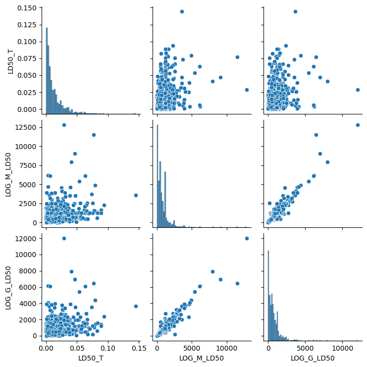

```python
ld50_columns = [
    'LD50_T',
    'LOG_M_LD50',
    'LOG_G_LD50'
]

_ = sns.pairplot(data_filtered_original[ld50_columns])
```

```python
print('Spearman rank correlation coefficients:')
(data_filtered_original[ld50_columns]).corr(method='spearman').round(2)
```

```
Spearman rank correlation coefficients:
```

|  | LD50_T | LOG_M_LD50 | LOG_G_LD50 |
| --- | --- | --- | --- |
| LD50_T | 1.00 | 0.57 | 0.57 |
| LOG_M_LD50 | 0.57 | 1.00 | 0.98 |
| LOG_G_LD50 | 0.57 | 0.98 | 1.00 |

## Configure each workflow

```python
# Map integer keys to descriptions/labels for visualization.
description_for_workflow = {
    1 : "Nicolo's workflow",
    2 : "Nicolo's workflow, no duplicates",
    3 : "Nicolo's workflow, no duplicates or metals",
    4 : "Our workflow, all features",
    5 : "Our workflow, median LD50",
    6 : "Our workflow, geo. mean LD50",
    7 : "Our workflow, TEST LD50"
}
```

### Define the features (X) & target variable (y)

```python
# Initialize containers.
X_for_workflow = {}
y_for_workflow = {}

# 1
X_for_workflow[1] = data_filtered_original[feature_columns]
y_for_workflow[1] = data_filtered_original[target_column]

# 2
X_for_workflow[2] = drop_duplicates(X_for_workflow[1])
y_for_workflow[2] = drop_duplicates(y_for_workflow[1])

# 3
X_for_workflow[3] = drop_duplicates_and_metals(data_filtered_original)[feature_columns]
y_for_workflow[3] = drop_duplicates_and_metals(data_filtered_original)[target_column]

# 4
data_filtered_updated = drop_duplicates_and_metals(study_count_filter(nicolo_data))
X_for_workflow[4] = data_filtered_updated[feature_columns]
y_for_workflow[4] = data_filtered_updated[target_column]

# 5
X_for_workflow[5] = (
    X_for_workflow[4]
    .drop(['LD50_T', 'LOG_G_LD50'], axis=1)
)
y_for_workflow[5] = y_for_workflow[4]

# 6
X_for_workflow[6] = (
    X_for_workflow[4]
    .drop(['LD50_T', 'LOG_M_LD50'], axis=1)
)
y_for_workflow[6] = y_for_workflow[4]

# 7
X_for_workflow[7] = (
    X_for_workflow[4]
    .drop(['LOG_M_LD50', 'LOG_G_LD50'], axis=1)
)
y_for_workflow[7] = y_for_workflow[4]
```

```python
# Inspect the resulting data.
for workflow, description in description_for_workflow.items():
    print(description)

    X = X_for_workflow[workflow]
    print(f'  Shape of X: {X.shape}')

    y = y_for_workflow[workflow]
    print(f'  Shape of y: {y.shape}')
```

```
Nicolo's workflow
  Shape of X: (1331, 16)
  Shape of y: (1331, 1)
Nicolo's workflow, no duplicates
  Shape of X: (1191, 16)
  Shape of y: (1191, 1)
Nicolo's workflow, no duplicates or metals
  Shape of X: (1122, 16)
  Shape of y: (1122, 1)
Our workflow, all features
  Shape of X: (1597, 16)
  Shape of y: (1597, 1)
Our workflow, median LD50
  Shape of X: (1597, 14)
  Shape of y: (1597, 1)
Our workflow, geo. mean LD50
  Shape of X: (1597, 14)
  Shape of y: (1597, 1)
Our workflow, TEST LD50
  Shape of X: (1597, 14)
  Shape of y: (1597, 1)
```

### Instantiate the estimators

Nicolo's workflow involves a Random Forest regressor with no feature preprocessing, whereas our workflow applies a pipeline for feature preprocessing.

```python
# Use the same random state for each estimator for comparability.
rng = 1
forest = RandomForestRegressor(random_state=rng, n_jobs=-1)

# Initialize a container.
estimator_for_workflow = {}

selector = (
    BasicFeatureSelector(
        thres_missing=0.25,  # threshold proportion missing
        thres_corr=0.9,  # threshold correlation coefficient
        method_corr='spearman')  # method
)

transformer = (
    Log10Transformer(
        alpha=0.05)  # significance level for skew test
)

imputer = (
    SimpleImputer(strategy='median')
)

scaler = (
    SelectiveScaler(
        measure='median')
)

pipeline = Pipeline(
    steps = [
        ('selector', selector),
        ('transformer', transformer),
        ('imputer', imputer),
        ('scaler', scaler),
        ('estimator', forest)
    ]
)

for workflow, description in description_for_workflow.items():
    if 'Nicolo' in description:
        estimator_for_workflow[workflow] = forest
    if 'Our' in description:
        estimator_for_workflow[workflow] = pipeline
```

## Implement each workflow with cross-validation

```python
%%time

# Initialize a container.
results_for_workflow = {}

for workflow, description in description_for_workflow.items():
    print(f'Running workflow {description}...')

    estimator = estimator_for_workflow[workflow]
    X = X_for_workflow[workflow]
    y = y_for_workflow[workflow]

    results_for_workflow[workflow] = repeated_kfold(
        estimator_for_workflow[workflow],
        X_for_workflow[workflow],
        y_for_workflow[workflow]
    )

r2_scores = (
    pd.concat(results_for_workflow, axis=1)
    .xs('r2_score', axis=1, level=-1)
    .rename(description_for_workflow, axis=1)
)
```

```
Running workflow Nicolo's workflow...
Running workflow Nicolo's workflow, no duplicates...
Running workflow Nicolo's workflow, no duplicates or metals...
Running workflow Our workflow, all features...
Running workflow Our workflow, median LD50...
Running workflow Our workflow, geo. mean LD50...
Running workflow Our workflow, TEST LD50...
CPU times: total: 1h 19min 44s
Wall time: 10min
```

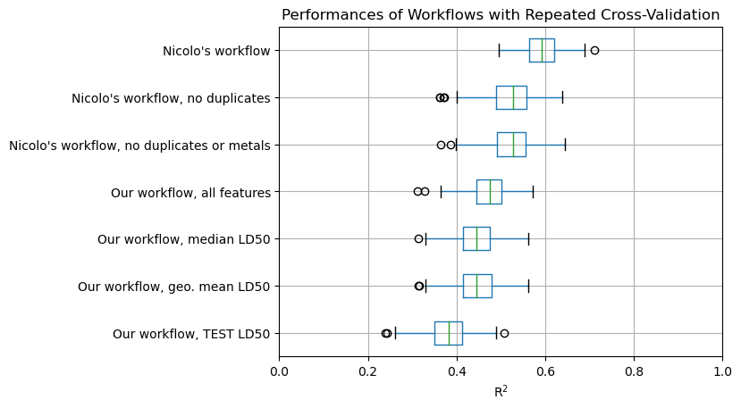

```python
xlim = (0., 1)
xlabel = 'R$^2$'
title = 'Performances of Workflows with Repeated Cross-Validation'

fig, ax = plt.subplots()

sorted_columns = list(r2_scores)[::-1]
ax = r2_scores[sorted_columns].boxplot(
    vert=False,
    ax=ax
)
ax.set_xlim(xlim)
ax.set_xlabel(xlabel)
_ = ax.set_title(title)
```

```python
r2_scores.describe().drop('count').round(2)
```

|  | Nicolo's workflow | Nicolo's workflow, no duplicates | Nicolo's workflow, no duplicates or metals | Our workflow, all features | Our workflow, median LD50 | Our workflow, geo. mean LD50 | Our workflow, TEST LD50 |
| --- | --- | --- | --- | --- | --- | --- | --- |
| mean | 0.59 | 0.52 | 0.52 | 0.47 | 0.44 | 0.44 | 0.38 |
| std | 0.04 | 0.05 | 0.05 | 0.04 | 0.04 | 0.05 | 0.05 |
| min | 0.49 | 0.36 | 0.36 | 0.31 | 0.31 | 0.31 | 0.24 |
| 25% | 0.56 | 0.49 | 0.49 | 0.45 | 0.41 | 0.42 | 0.35 |
| 50% | 0.59 | 0.53 | 0.53 | 0.48 | 0.45 | 0.44 | 0.38 |
| 75% | 0.62 | 0.56 | 0.56 | 0.50 | 0.47 | 0.48 | 0.41 |
| max | 0.71 | 0.64 | 0.64 | 0.57 | 0.56 | 0.56 | 0.51 |

## Compare with our updated features (CompTox 2023)

Nicolo's analysis was written >2 years ago. As such, the feature data may be outdated. Below, we will examine the updated feature data that I recently downloaded to further explore the question regarding metals (as we've defined them) and data availability.

As Prof. Chiu mentioned,

```
You may need to check the opera workflow as to how they filtered out metals/metallics...We may want to adopt the same filtering method.
```

OPERA uses a standardization workflow to generate "QSAR-ready" chemical structures: https://github.com/NIEHS/QSAR-ready/releases/tag/2.5.8

### Load all updated features

```python
updated_features_path = path.join(
    'Features',
    'chemical-properties.csv')

updated_features = pd.read_csv(
    updated_features_path,
    index_col='DTXSID')

identifiers_path = path.join(
    'Source',
    'CompTox',
    'CCD-identifiers.csv')

updated_identifiers = pd.read_csv(
    identifiers_path,
    index_col=index_col)

id_columns = [
    'MOLECULAR_FORMULA',
    'QSAR_READY_SMILES'
]

updated_features_join = updated_identifiers[id_columns].join(updated_features)

updated_features_join
```

| DTXSID | MOLECULAR_FORMULA | QSAR_READY_SMILES | AVERAGE_MASS | 48HR_DAPHNIA_LC50_MOL/L_TEST_PRED | DENSITY_G/CM^3_TEST_PRED | DEVTOX_TEST_PRED | 96HR_FATHEAD_MINNOW_MOL/L_TEST_PRED | FLASH_POINT_DEGC_TEST_PRED | AMES_MUTAGENICITY_TEST_PRED | ORAL_RAT_LD50_MOL/KG_TEST_PRED | ... | HENRYS_LAW_ATM-M3/MOLE_OPERA_PRED | OPERA_KM_DAYS_OPERA_PRED | OCTANOL_AIR_PARTITION_COEFF_LOGKOA_OPERA_PRED | SOIL_ADSORPTION_COEFFICIENT_KOC_L/KG_OPERA_PRED | OCTANOL_WATER_PARTITION_LOGP_OPERA_PRED | MELTING_POINT_DEGC_OPERA_PRED | OPERA_PKAA_OPERA_PRED | OPERA_PKAB_OPERA_PRED | VAPOR_PRESSURE_MMHG_OPERA_PRED | WATER_SOLUBILITY_MOL/L_OPERA_PRED |
| --- | --- | --- | --- | --- | --- | --- | --- | --- | --- | --- | --- | --- | --- | --- | --- | --- | --- | --- | --- | --- | --- |
| DTXSID5020281 | C6H4ClNO2 | [O-][N+](=O)C1=CC=C(Cl)C=C1 | 157.550 | 1.081430e-04 | 1.372 | 0.323 | 5.714790e-05 | 109.227 | 0.966 | 0.007079 | ... | 4.947790e-06 | 0.332365 | 4.32722 | 507.6930 | 2.391540 | 82.9942 | NaN | NaN | 2.203470e-02 | 1.317610e-03 |
| DTXSID8020961 | C6H6N2O2 | NC1=CC=C(C=C1)[N+]([O-])=O | 138.126 | 6.486340e-05 | 1.309 | 0.250 | 4.385310e-04 | 141.229 | 0.642 | 0.009141 | ... | 1.265030e-09 | 0.306715 | 6.57226 | 75.9962 | 1.388040 | 145.5400 | NaN | 1.03 | 3.265100e-06 | 4.815930e-03 |
| DTXSID0021834 | C6H5NO3 | OC1=CC=C(C=C1)[N+]([O-])=O | 139.110 | 5.395110e-05 | 1.376 | 0.281 | 1.472310e-04 | 117.588 | 0.490 | 0.005140 | ... | 4.207650e-10 | 0.251436 | 6.11321 | 233.1200 | 1.912110 | 113.5640 | 7.13 | NaN | 9.970590e-05 | 9.679290e-02 |
| DTXSID3032622 | C4H5NO2 | CC1=CC(=O)NO1 | 99.089 | NaN | 1.276 | 0.639 | NaN | 36.844 | 0.372 | 0.004457 | ... | 9.095360e-08 | 0.288388 | 4.73187 | 10.0605 | 0.455232 | 86.5110 | NaN | NaN | 1.396390e-03 | 8.066960e-01 |
| DTXSID2044347 | C9H10O2 | COC1=CC=C(C=C1)C(C)=O | 150.177 | 1.312200e-04 | 1.072 | 0.621 | 2.904020e-04 | 98.358 | 0.305 | 0.004887 | ... | 9.683370e-08 | 0.279812 | 5.07316 | 98.5113 | 1.742920 | 37.4772 | NaN | NaN | 6.500820e-03 | 1.201570e-02 |
| ... | ... | ... | ... | ... | ... | ... | ... | ... | ... | ... | ... | ... | ... | ... | ... | ... | ... | ... | ... | ... | ... |
| DTXSID5057882 | C14H12Cl2FNO | CC(N)C1=CC(F)=CC=C1OC1=CC=C(Cl)C(Cl)=C1 | 300.150 | 2.065380e-07 | 1.363 | 0.679 | 7.211070e-07 | 187.442 | 0.313 | NaN | ... | 2.333810e-07 | 3.627750 | 10.62620 | 8156.8700 | 3.845500 | 161.2890 | NaN | NaN | 2.468280e-07 | 1.982760e-06 |
| DTXSID5057884 | C20H22Cl2N2O3 | O[C@H]1CCN(C[C@@H](N(O)C(=O)CC2=CC(Cl)=C(Cl)C=... | 409.310 | NaN | 1.434 | 0.933 | NaN | 297.064 | 0.200 | NaN | ... | 1.494930e-10 | 0.148214 | 9.54575 | 2186.0300 | 2.907920 | 181.9450 | NaN | NaN | 1.335850e-09 | 3.015700e-05 |
| DTXSID0057885 | C27H26F3N3O2 | CC(=O)NCCN1CCC2=CC(NC(=O)C3=CC=CC=C3C3=CC=C(C=... | 481.519 | 8.035260e-06 | 1.289 | 1.027 | 1.009250e-07 | 324.706 | 0.049 | NaN | ... | 6.479200e-10 | 1.686170 | 9.67654 | 161483.0000 | 5.490790 | 168.4210 | NaN | NaN | 2.338530e-09 | 3.245060e-08 |
| DTXSID1057905 | NaN | NaN | NaN | NaN | NaN | NaN | NaN | NaN | NaN | NaN | ... | NaN | NaN | NaN | NaN | NaN | NaN | NaN | NaN | NaN | NaN |
| DTXSID6057906 | C26H32N2O6S2 | CCC(C)C(NC(=O)C1=CC=CC=C1SSC1=CC=CC=C1C(=O)NC(... | 532.670 | NaN | NaN | NaN | NaN | NaN | NaN | NaN | ... | NaN | NaN | NaN | NaN | NaN | NaN | NaN | NaN | NaN | NaN |

6598 rows × 28 columns

### Apply the first filter in our workflow

```python
updated_features_join = updated_features_join.dropna(
    subset='MOLECULAR_FORMULA')

updated_features_join
```

| DTXSID | MOLECULAR_FORMULA | QSAR_READY_SMILES | AVERAGE_MASS | 48HR_DAPHNIA_LC50_MOL/L_TEST_PRED | DENSITY_G/CM^3_TEST_PRED | DEVTOX_TEST_PRED | 96HR_FATHEAD_MINNOW_MOL/L_TEST_PRED | FLASH_POINT_DEGC_TEST_PRED | AMES_MUTAGENICITY_TEST_PRED | ORAL_RAT_LD50_MOL/KG_TEST_PRED | ... | HENRYS_LAW_ATM-M3/MOLE_OPERA_PRED | OPERA_KM_DAYS_OPERA_PRED | OCTANOL_AIR_PARTITION_COEFF_LOGKOA_OPERA_PRED | SOIL_ADSORPTION_COEFFICIENT_KOC_L/KG_OPERA_PRED | OCTANOL_WATER_PARTITION_LOGP_OPERA_PRED | MELTING_POINT_DEGC_OPERA_PRED | OPERA_PKAA_OPERA_PRED | OPERA_PKAB_OPERA_PRED | VAPOR_PRESSURE_MMHG_OPERA_PRED | WATER_SOLUBILITY_MOL/L_OPERA_PRED |
| --- | --- | --- | --- | --- | --- | --- | --- | --- | --- | --- | --- | --- | --- | --- | --- | --- | --- | --- | --- | --- | --- |
| DTXSID5020281 | C6H4ClNO2 | [O-][N+](=O)C1=CC=C(Cl)C=C1 | 157.550 | 1.081430e-04 | 1.372 | 0.323 | 5.714790e-05 | 109.227 | 0.966 | 0.007079 | ... | 4.947790e-06 | 0.332365 | 4.32722 | 507.6930 | 2.391540 | 82.9942 | NaN | NaN | 2.203470e-02 | 1.317610e-03 |
| DTXSID8020961 | C6H6N2O2 | NC1=CC=C(C=C1)[N+]([O-])=O | 138.126 | 6.486340e-05 | 1.309 | 0.250 | 4.385310e-04 | 141.229 | 0.642 | 0.009141 | ... | 1.265030e-09 | 0.306715 | 6.57226 | 75.9962 | 1.388040 | 145.5400 | NaN | 1.03 | 3.265100e-06 | 4.815930e-03 |
| DTXSID0021834 | C6H5NO3 | OC1=CC=C(C=C1)[N+]([O-])=O | 139.110 | 5.395110e-05 | 1.376 | 0.281 | 1.472310e-04 | 117.588 | 0.490 | 0.005140 | ... | 4.207650e-10 | 0.251436 | 6.11321 | 233.1200 | 1.912110 | 113.5640 | 7.13 | NaN | 9.970590e-05 | 9.679290e-02 |
| DTXSID3032622 | C4H5NO2 | CC1=CC(=O)NO1 | 99.089 | NaN | 1.276 | 0.639 | NaN | 36.844 | 0.372 | 0.004457 | ... | 9.095360e-08 | 0.288388 | 4.73187 | 10.0605 | 0.455232 | 86.5110 | NaN | NaN | 1.396390e-03 | 8.066960e-01 |
| DTXSID2044347 | C9H10O2 | COC1=CC=C(C=C1)C(C)=O | 150.177 | 1.312200e-04 | 1.072 | 0.621 | 2.904020e-04 | 98.358 | 0.305 | 0.004887 | ... | 9.683370e-08 | 0.279812 | 5.07316 | 98.5113 | 1.742920 | 37.4772 | NaN | NaN | 6.500820e-03 | 1.201570e-02 |
| ... | ... | ... | ... | ... | ... | ... | ... | ... | ... | ... | ... | ... | ... | ... | ... | ... | ... | ... | ... | ... | ... |
| DTXSID5057880 | C17H20ClNO3S | CNCC1=CC=C(C=C1OC1=C(C)C(C)=C(Cl)C=C1)S(C)(=O)=O | 353.860 | 7.144960e-06 | 1.256 | 0.846 | 1.023290e-06 | 261.844 | 0.204 | NaN | ... | 2.941970e-07 | 1.655430 | 10.64380 | 961.6230 | 2.950650 | 125.4470 | NaN | NaN | 6.420140e-08 | 5.643740e-07 |
| DTXSID5057882 | C14H12Cl2FNO | CC(N)C1=CC(F)=CC=C1OC1=CC=C(Cl)C(Cl)=C1 | 300.150 | 2.065380e-07 | 1.363 | 0.679 | 7.211070e-07 | 187.442 | 0.313 | NaN | ... | 2.333810e-07 | 3.627750 | 10.62620 | 8156.8700 | 3.845500 | 161.2890 | NaN | NaN | 2.468280e-07 | 1.982760e-06 |
| DTXSID5057884 | C20H22Cl2N2O3 | O[C@H]1CCN(C[C@@H](N(O)C(=O)CC2=CC(Cl)=C(Cl)C=... | 409.310 | NaN | 1.434 | 0.933 | NaN | 297.064 | 0.200 | NaN | ... | 1.494930e-10 | 0.148214 | 9.54575 | 2186.0300 | 2.907920 | 181.9450 | NaN | NaN | 1.335850e-09 | 3.015700e-05 |
| DTXSID0057885 | C27H26F3N3O2 | CC(=O)NCCN1CCC2=CC(NC(=O)C3=CC=CC=C3C3=CC=C(C=... | 481.519 | 8.035260e-06 | 1.289 | 1.027 | 1.009250e-07 | 324.706 | 0.049 | NaN | ... | 6.479200e-10 | 1.686170 | 9.67654 | 161483.0000 | 5.490790 | 168.4210 | NaN | NaN | 2.338530e-09 | 3.245060e-08 |
| DTXSID6057906 | C26H32N2O6S2 | CCC(C)C(NC(=O)C1=CC=CC=C1SSC1=CC=CC=C1C(=O)NC(... | 532.670 | NaN | NaN | NaN | NaN | NaN | NaN | NaN | ... | NaN | NaN | NaN | NaN | NaN | NaN | NaN | NaN | NaN | NaN |

5436 rows × 28 columns

### Identify any remaining metals

```python
n_missing_total = updated_features_join.isna().sum()

metals = comptox.chemicals_with_metal(
    updated_features_join['MOLECULAR_FORMULA']
)
n_missing_metals = updated_features_join.loc[metals].isna().sum()

missing_comparison = (
    pd.DataFrame(
        [n_missing_metals, n_missing_total]
        , index=['metals', 'total'])
    .T
    .drop('MOLECULAR_FORMULA')
    .reset_index()
)
```

```python
len(metals), len(updated_features_join)
```

```
(1251, 5436)
```

### Compare the availability of QSAR-predicted features: metals vs. non-metals

"QSAR-ready SMILES" is included for comparison.

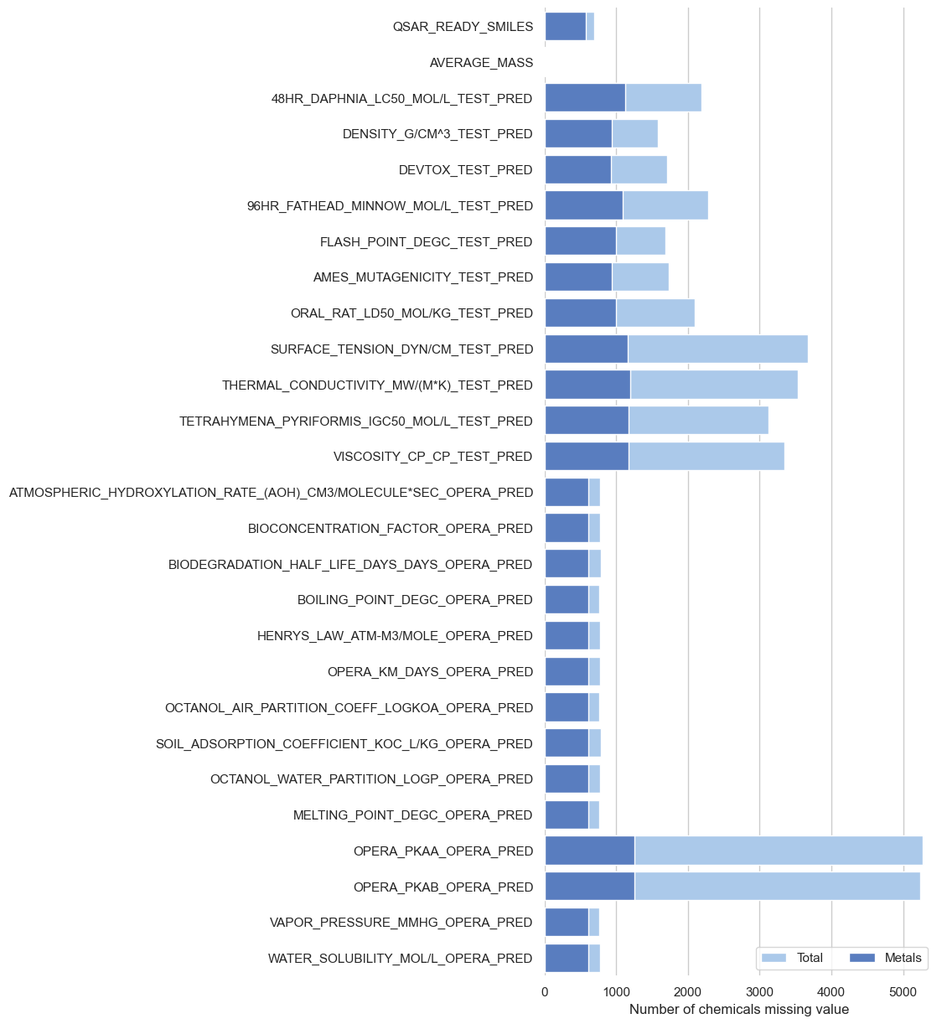

```python
sns.set_theme(style="whitegrid")

# Initialize the matplotlib figure
f, ax = plt.subplots(figsize=(6, 15))

sns.set_color_codes("pastel")
sns.barplot(x="total", y="index", data=missing_comparison,
            label="Total", color="b")

sns.set_color_codes("muted")
sns.barplot(x="metals", y="index", data=missing_comparison,
            label="Metals", color="b")

# Add a legend and informative axis label
ax.legend(ncol=2, loc="lower right", frameon=True)
ax.set(xlim=(0, len(updated_features_join)), ylabel="",
       xlabel="Number of chemicals missing value")
sns.despine(left=True, bottom=True)
```

### One possible way to proceed: include only chemicals with "QSAR-ready SMILES" from CompTox?

Theoretically, these chemicals should have cleared all filters in the standardization workflow used by OPERA.